```r
library(dplyr)
library(ggplot2)
```

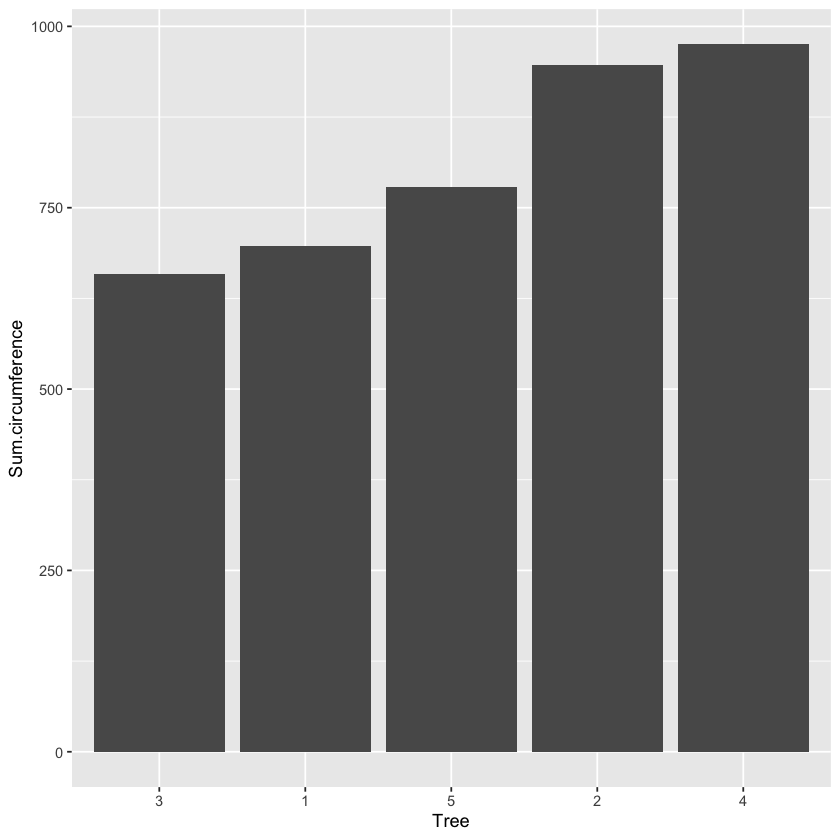

```r
Orange%>%
  group_by(Tree)%>%
  summarize(Sum.circumference=sum(circumference))%>%
  ggplot(aes(Tree, Sum.circumference))+geom_bar(stat='identity')
```

# 1. 그래프를 기반으로 geom 함수에 적용하기

- 완성된 그래프에 색상을 입혀 명시성을 높여주는 방식
- bar, line, point 그래프 등 그래프 종류에 상관없이 geom_함수에 color='x 혹은 fill='x'함수를 추가하고, x에는 원하는 색상을 넣어주면 됨

## 1) fill

- fill 함수는 도형에 색을 채워줄 때 사용
- bar 그래프와 오차 그래프 등 채울 공간이 있는 도형애 색상을 채워 줌

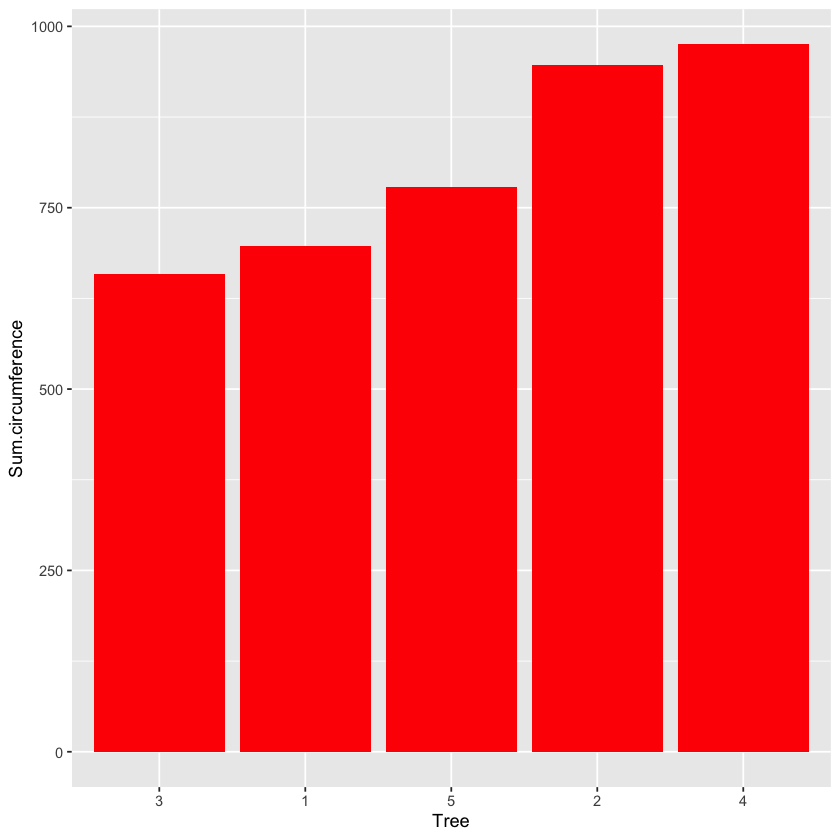

```r
# geom_bar() 함수에 fill='red' 코드를 추가해 bar 그래프에 빨간색을 입혀줌
Orange%>%
    group_by(Tree)%>%
    summarize(Sum.circumference=sum(circumference))%>%
    ggplot(aes(Tree, Sum.circumference)) + geom_bar(stat='identity', fill='red')
```

## 2) color

- R에서 color 함수는 선의 색깔을 채워줄 때 사용하는 함수
- Bar 그래프의 테두리, Line 그래프의 색상, 경우에 따라 Point 그래프의 Point 테두리 등에 색상을 채워 줌
- 선의 색상을 입히기 위한 코드는 color='x'에 원하는 색상을 입력하면 됨

### (1) bar 그래프

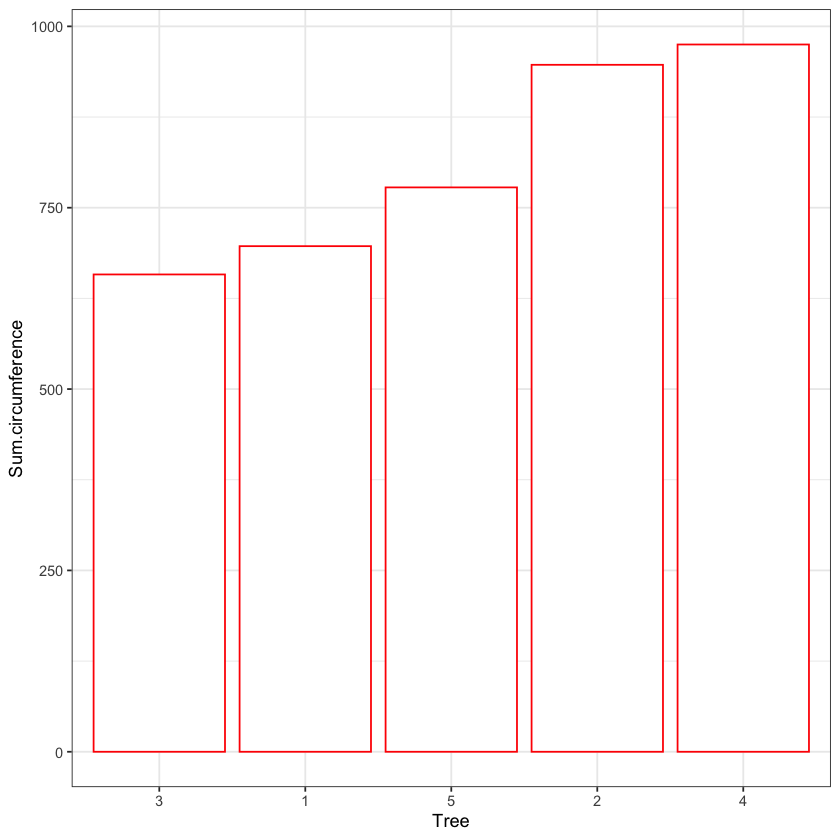

```r
# geom_bar() 함수에 color='red' 코드를 추가하여 bar 그래프 테두리 색을 변경해 줌
Orange%>%
    group_by(Tree)%>%
    summarize(Sum.circumference=sum(circumference))%>%
    ggplot(aes(Tree, Sum.circumference)) +
    geom_bar(stat='identity', color='red', fill='white') +
    theme_bw()
```

### (2) line 그래프

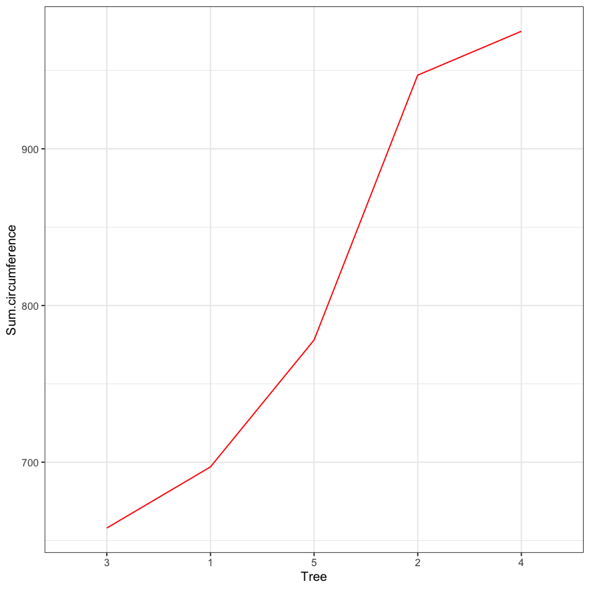

```r
# geom_line() 함수에 color='red' 코드를 추가해 그래프 색상을 빨간색으로 변경
Orange%>%
    group_by(Tree)%>%
    summarize(Sum.circumference=sum(circumference))%>%
    ggplot(aes(Tree, Sum.circumference)) + geom_line(group=1, color='red') +
    theme_bw()
```

### (3) point 그래프

- point 그래프는 shape 함수를 통해 어떤 모양으로 설정해 주느냐에 따라 color와 fill을 다르게 설정할 수 있음
- point의 shape은 -8부터 29까지 있으며, -8부터 19까지는 color 함수로 적용이 가능하고, 20부터 29까지는 color와 fill 함수 모두를 활용해 테두리와 도형색을 독립적으로 설정해줄 수 있음

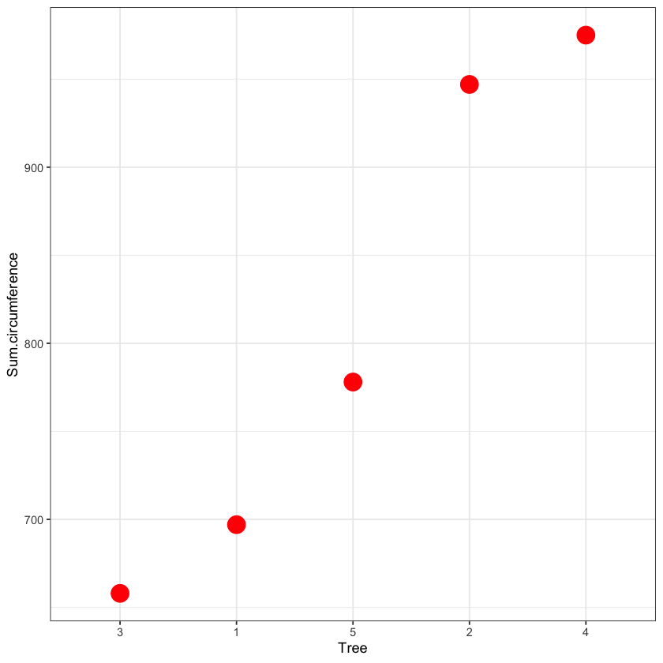

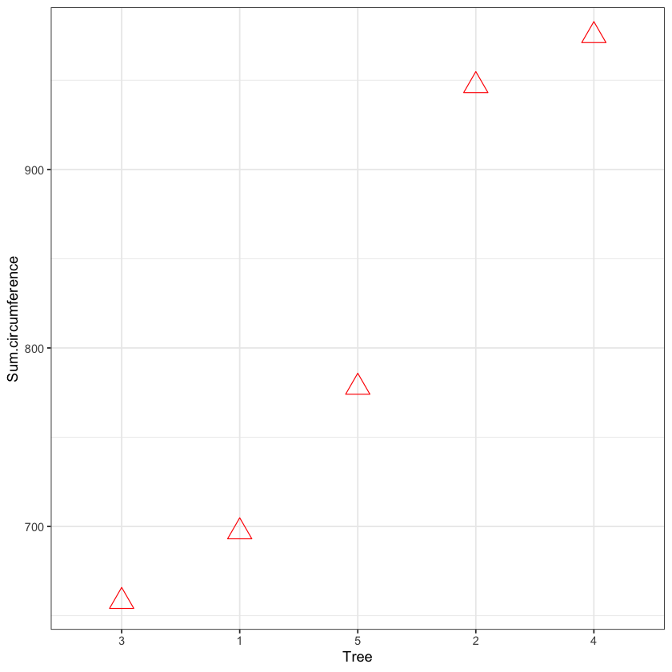

```r
# circle
Orange%>%
    group_by(Tree)%>%
    summarize(Sum.circumference=sum(circumference))%>%
    ggplot(aes(Tree, Sum.circumference)) +
    geom_point(size=6, color='red') +
    theme_bw()

# triangle
Orange%>%
    group_by(Tree)%>%
    summarize(Sum.circumference=sum(circumference))%>%
    ggplot(aes(Tree, Sum.circumference)) +
    geom_point(shape=2, size=6, color='red') +
    theme_bw()
```

# 2. 데이터를 기반으로 aes함수에 적용하기

- color과 fill 함수는 그래프의 도형 외에도 데이터에 색상을 입혀줄 수 있음
- aes함수는 그래프의 틀을 만들어주는 함수, 따라서 aes함수에는 그래프를 형성하는데 필요한 정보인 x축과 y축 등을 설정해 줌
- geom()에 color와 fill을 입력했던 것과 달리, color 혹은 fill 함수를 데이터를 바탕으로 하는 aes() 함수에 입력한다면 데이터에 색상이 입혀짐

## 1) line 그래프

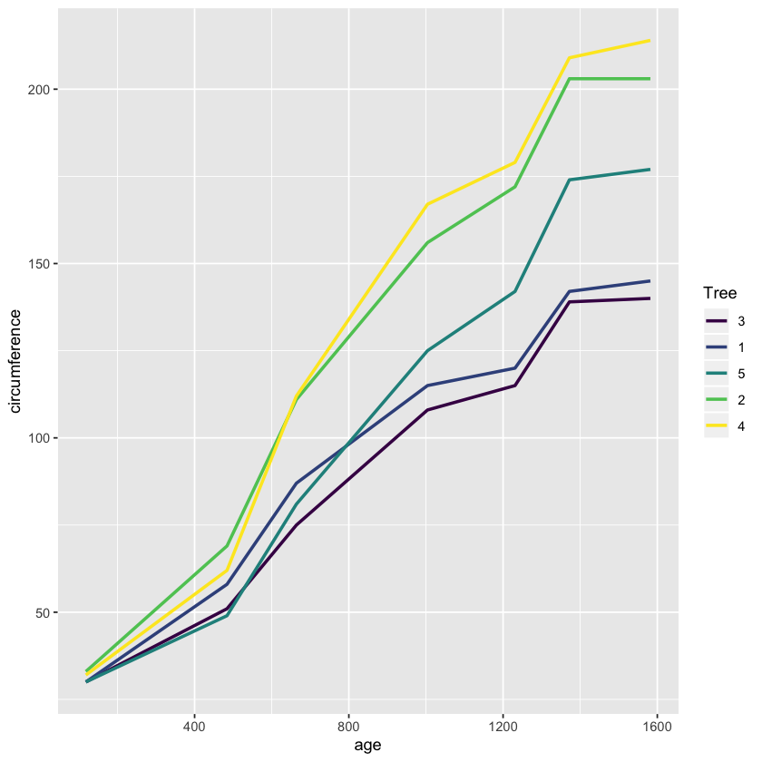

```r
ggplot(Orange, aes(x=age, y=circumference, color=Tree)) + geom_line(size=1)
```

## 2) bar 그래프

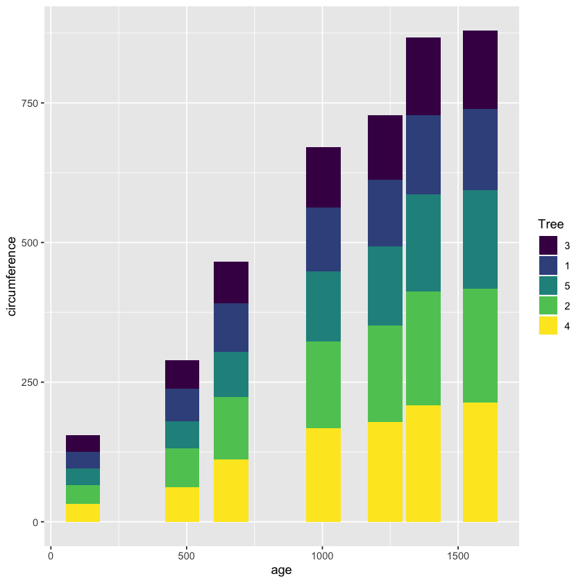

```r
ggplot(Orange, aes(x=age, y=circumference, fill=Tree)) + geom_bar(stat='identity')
```

## 3) point 그래프

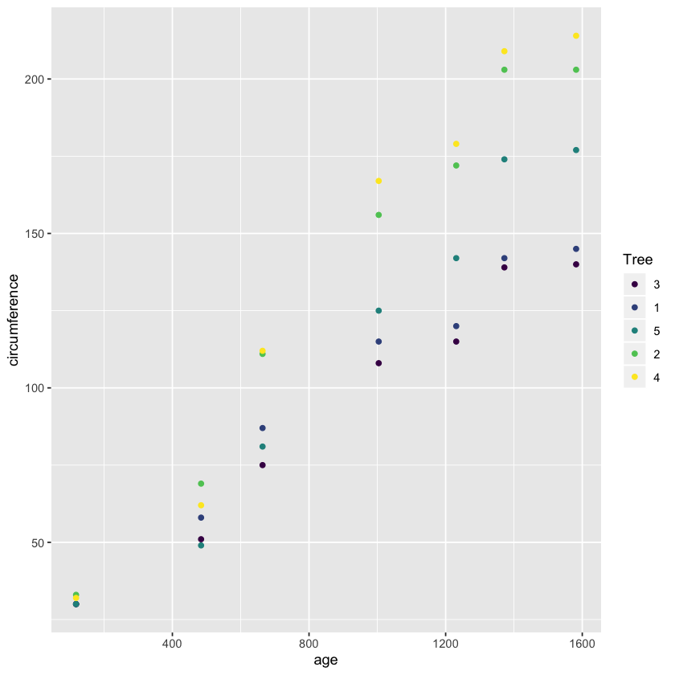

```r
ggplot(Orange, aes(x=age, y=circumference, color=Tree)) + geom_point()
```